# CreditCardChurn

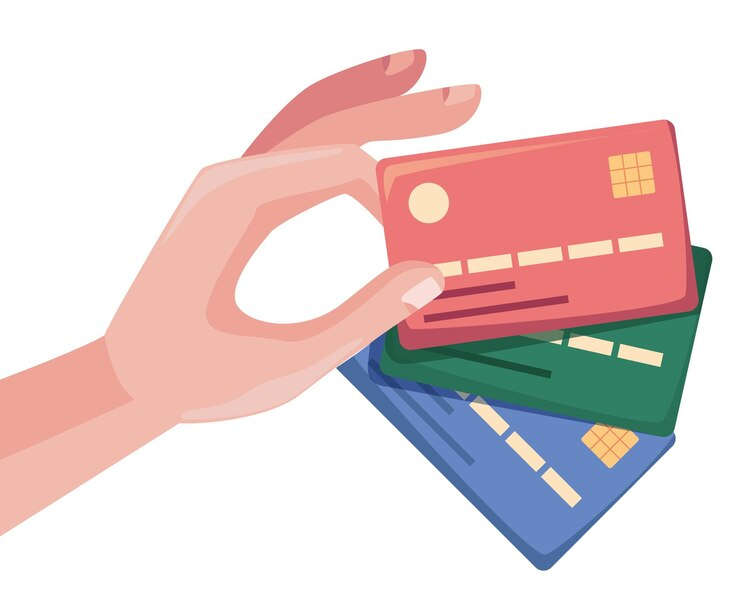

**CONTEXT**

The Thera bank recently saw a steep decline in the number of users of their credit card, credit cards are a good source of income for banks because of different kinds of fees charged by the banks like annual fees, balance transfer fees, and cash advance fees, late payment fees, foreign transaction fees, and others. Some fees are charged to every user irrespective of usage, while others are charged under specified circumstances.

**OBJECTIVE**

Customers’ leaving credit card services would lead the bank to loss, so the bank wants to analyze the data of customers and identify the customers who will leave their credit card services and the reason for same – so that the bank could improve upon those areas. We need to explore the data provided, identify patterns, and come up with a classification model to identify customers likely to churn, and provide actionable insights and recommendations that will help the bank improve its services so that customers do not renounce their credit cards.

```python
import pandas as pd
import numpy as np
import matplotlib.pyplot as plt
import seaborn as sns
from sklearn.model_selection import train_test_split, StratifiedKFold, cross_val_score, cross_validate, cross_val_predict, RandomizedSearchCV
from sklearn.preprocessing import RobustScaler
from sklearn.tree import DecisionTreeClassifier
from sklearn.ensemble import RandomForestClassifier, BaggingClassifier, AdaBoostClassifier, GradientBoostingClassifier
from sklearn.pipeline import Pipeline
from sklearn.metrics import confusion_matrix, classification_report, make_scorer, recall_score, accuracy_score, precision_score, f1_score, RocCurveDisplay
from imblearn.over_sampling import SMOTE
from imblearn.under_sampling import RandomUnderSampler

%cd C:\Users\ajays\Dropbox\PGP-AIML\projects\creditcardchurn
```

```
C:\Users\ajays\Dropbox\PGP-AIML\projects\creditcardchurn
```

## Exploratory Data Analysis

```python
df = pd.read_csv('BankChurners.csv')
df.head()
```

|  | CLIENTNUM | Attrition_Flag | Customer_Age | Gender | Dependent_count | Education_Level | Marital_Status | Income_Category | Card_Category | Months_on_book | ... | Months_Inactive_12_mon | Contacts_Count_12_mon | Credit_Limit | Total_Revolving_Bal | Avg_Open_To_Buy | Total_Amt_Chng_Q4_Q1 | Total_Trans_Amt | Total_Trans_Ct | Total_Ct_Chng_Q4_Q1 | Avg_Utilization_Ratio |
| --- | --- | --- | --- | --- | --- | --- | --- | --- | --- | --- | --- | --- | --- | --- | --- | --- | --- | --- | --- | --- | --- |
| 0 | 768805383 | Existing Customer | 45 | M | 3 | High School | Married | $60K - $80K | Blue | 39 | ... | 1 | 3 | 12691.0 | 777 | 11914.0 | 1.335 | 1144 | 42 | 1.625 | 0.061 |
| 1 | 818770008 | Existing Customer | 49 | F | 5 | Graduate | Single | Less than $40K | Blue | 44 | ... | 1 | 2 | 8256.0 | 864 | 7392.0 | 1.541 | 1291 | 33 | 3.714 | 0.105 |
| 2 | 713982108 | Existing Customer | 51 | M | 3 | Graduate | Married | $80K - $120K | Blue | 36 | ... | 1 | 0 | 3418.0 | 0 | 3418.0 | 2.594 | 1887 | 20 | 2.333 | 0.000 |
| 3 | 769911858 | Existing Customer | 40 | F | 4 | High School | NaN | Less than $40K | Blue | 34 | ... | 4 | 1 | 3313.0 | 2517 | 796.0 | 1.405 | 1171 | 20 | 2.333 | 0.760 |
| 4 | 709106358 | Existing Customer | 40 | M | 3 | Uneducated | Married | $60K - $80K | Blue | 21 | ... | 1 | 0 | 4716.0 | 0 | 4716.0 | 2.175 | 816 | 28 | 2.500 | 0.000 |

5 rows × 21 columns

```python
df.shape
```

```
(10127, 21)
```

- *The dataset has* *10127 rows and 21 columns***

```python
df.info()
```

```
<class 'pandas.core.frame.DataFrame'>
RangeIndex: 10127 entries, 0 to 10126
Data columns (total 21 columns):
 #   Column                    Non-Null Count  Dtype
---  ------                    --------------  -----
 0   CLIENTNUM                 10127 non-null  int64
 1   Attrition_Flag            10127 non-null  object
 2   Customer_Age              10127 non-null  int64
 3   Gender                    10127 non-null  object
 4   Dependent_count           10127 non-null  int64
 5   Education_Level           8608 non-null   object
 6   Marital_Status            9378 non-null   object
 7   Income_Category           10127 non-null  object
 8   Card_Category             10127 non-null  object
 9   Months_on_book            10127 non-null  int64
 10  Total_Relationship_Count  10127 non-null  int64
 11  Months_Inactive_12_mon    10127 non-null  int64
 12  Contacts_Count_12_mon     10127 non-null  int64
 13  Credit_Limit              10127 non-null  float64
 14  Total_Revolving_Bal       10127 non-null  int64
 15  Avg_Open_To_Buy           10127 non-null  float64
 16  Total_Amt_Chng_Q4_Q1      10127 non-null  float64
 17  Total_Trans_Amt           10127 non-null  int64
 18  Total_Trans_Ct            10127 non-null  int64
 19  Total_Ct_Chng_Q4_Q1       10127 non-null  float64
 20  Avg_Utilization_Ratio     10127 non-null  float64
dtypes: float64(5), int64(10), object(6)
memory usage: 1.6+ MB
```

```python
df['CLIENTNUM'].nunique()
```

```
10127
```

- ***CLIENTNUM** is a unique identifier for the client and has 10127 unique values , equal in number to the total number of rows in the data set. Since this **does not have any bearing on the eventual model or any analysis**, we can safely **drop this column** before further processing*

```python
df.drop(columns=['CLIENTNUM'], inplace=True)
```

```python
df['Attrition_Flag'].unique()
```

```
array(['Existing Customer', 'Attrited Customer'], dtype=object)
```

```python
df['Attrition_Flag'].value_counts()
```

```
Attrition_Flag
Existing Customer    8500
Attrited Customer    1627
Name: count, dtype: int64
```

- *Attrition_Flag has no missing values and has 2 possible values.* *'Existing Customer' s are in majority class compared to 'Attrited Customer's***
- ***Atrrition_Flag is the target variable** based on the intention of the problem statement*

```python
df['Gender'].unique()
```

```
array(['M', 'F'], dtype=object)
```

```python
df['Gender'].value_counts()
```

```
Gender
F    5358
M    4769
Name: count, dtype: int64
```

- ***Gender** has **no missing values** and has 2 possible values. Both **'M' and 'F' have similar representation***

```python
df['Education_Level'].unique()
```

```
array(['High School', 'Graduate', 'Uneducated', nan, 'College',
       'Post-Graduate', 'Doctorate'], dtype=object)
```

```python
df['Education_Level'].value_counts()
```

```
Education_Level
Graduate         3128
High School      2013
Uneducated       1487
College          1013
Post-Graduate     516
Doctorate         451
Name: count, dtype: int64
```

- ***Education_Level has some missing values (NaN)**. Other than these rows there are 6 possible unique values. The highest number of people **3128 have 'Graduate' as their highest level** whereas the lowest value of people **451 have 'Doctorate'***

```python
df['Marital_Status'].unique()
```

```
array(['Married', 'Single', nan, 'Divorced'], dtype=object)
```

```python
df['Marital_Status'].value_counts()
```

```
Marital_Status
Married     4687
Single      3943
Divorced     748
Name: count, dtype: int64
```

- ***Marital_Status has some missing values (NaN)**. Other than these rows there are 3 possible unique values. **'Married' and 'Single' have almost equal representation** whereas there are **fewer 'Divorced'***

```python
df['Income_Category'].unique()
```

```
array(['$60K - $80K', 'Less than $40K', '$80K - $120K', '$40K - $60K',
       '$120K +', 'abc'], dtype=object)
```

```python
df['Income_Category'].value_counts()
```

```
Income_Category
Less than $40K    3561
$40K - $60K       1790
$80K - $120K      1535
$60K - $80K       1402
abc               1112
$120K +            727
Name: count, dtype: int64
```

- ***Income_Category** has no missing values, but has some **rows marked 'abc' which seems to be an invalid category**. This may need further analysis and treatment.*
- *Other than the above, the feature has 5 possible values with* *'Less than $40K' having the highest representation***

```python
df['Card_Category'].unique()
```

```
array(['Blue', 'Gold', 'Silver', 'Platinum'], dtype=object)
```

```python
df['Card_Category'].value_counts()
```

```
Card_Category
Blue        9436
Silver       555
Gold         116
Platinum      20
Name: count, dtype: int64
```

- ***Card_Category** seems to have valid values for all rows with **'Blue' having the highest number and 'Platinum' the lowest***

```python
df.describe().T.apply(lambda s: s.apply('{0:.3f}'.format))
```

|  | count | mean | std | min | 25% | 50% | 75% | max |
| --- | --- | --- | --- | --- | --- | --- | --- | --- |
| Customer_Age | 10127.000 | 46.326 | 8.017 | 26.000 | 41.000 | 46.000 | 52.000 | 73.000 |
| Dependent_count | 10127.000 | 2.346 | 1.299 | 0.000 | 1.000 | 2.000 | 3.000 | 5.000 |
| Months_on_book | 10127.000 | 35.928 | 7.986 | 13.000 | 31.000 | 36.000 | 40.000 | 56.000 |
| Total_Relationship_Count | 10127.000 | 3.813 | 1.554 | 1.000 | 3.000 | 4.000 | 5.000 | 6.000 |
| Months_Inactive_12_mon | 10127.000 | 2.341 | 1.011 | 0.000 | 2.000 | 2.000 | 3.000 | 6.000 |
| Contacts_Count_12_mon | 10127.000 | 2.455 | 1.106 | 0.000 | 2.000 | 2.000 | 3.000 | 6.000 |
| Credit_Limit | 10127.000 | 8631.954 | 9088.777 | 1438.300 | 2555.000 | 4549.000 | 11067.500 | 34516.000 |
| Total_Revolving_Bal | 10127.000 | 1162.814 | 814.987 | 0.000 | 359.000 | 1276.000 | 1784.000 | 2517.000 |
| Avg_Open_To_Buy | 10127.000 | 7469.140 | 9090.685 | 3.000 | 1324.500 | 3474.000 | 9859.000 | 34516.000 |
| Total_Amt_Chng_Q4_Q1 | 10127.000 | 0.760 | 0.219 | 0.000 | 0.631 | 0.736 | 0.859 | 3.397 |
| Total_Trans_Amt | 10127.000 | 4404.086 | 3397.129 | 510.000 | 2155.500 | 3899.000 | 4741.000 | 18484.000 |
| Total_Trans_Ct | 10127.000 | 64.859 | 23.473 | 10.000 | 45.000 | 67.000 | 81.000 | 139.000 |
| Total_Ct_Chng_Q4_Q1 | 10127.000 | 0.712 | 0.238 | 0.000 | 0.582 | 0.702 | 0.818 | 3.714 |
| Avg_Utilization_Ratio | 10127.000 | 0.275 | 0.276 | 0.000 | 0.023 | 0.176 | 0.503 | 0.999 |

### Univariate analysis

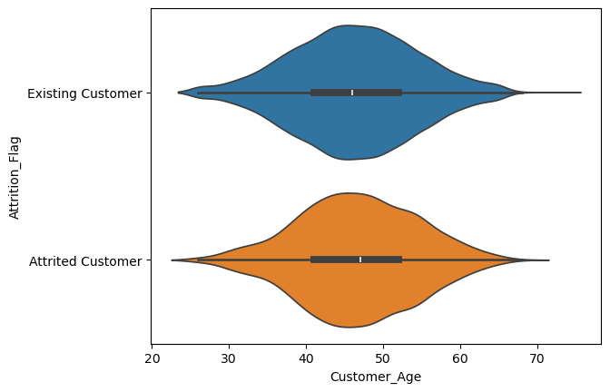

```python
sns.violinplot(data=df, x='Customer_Age', hue='Attrition_Flag', y='Attrition_Flag')
```

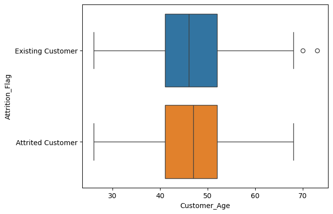

```python
sns.boxplot(data=df, x='Customer_Age', hue='Attrition_Flag', y='Attrition_Flag')
```

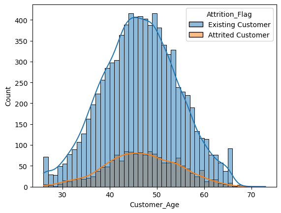

```python
sns.histplot(data=df, x='Customer_Age', hue='Attrition_Flag', kde=True)
```

- ***Customer_Age** is almost **normally distributed** for both existing and attrited customers*

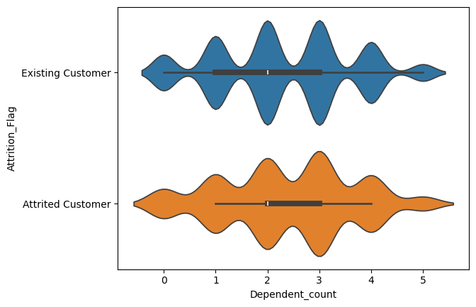

```python
sns.violinplot(data=df, x='Dependent_count', hue='Attrition_Flag', y='Attrition_Flag')
```

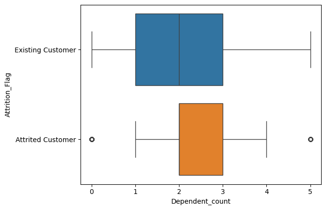

```python
sns.boxplot(data=df, x='Dependent_count', hue='Attrition_Flag', y='Attrition_Flag')
```

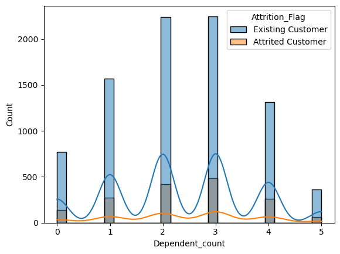

```python
sns.histplot(data=df, x='Dependent_count', hue='Attrition_Flag', kde=True)
```

- ***Dependent_count** has **discrete values** from 0 - 5 for all the rows*
- *Max number of customers of both classes have* *2 or 3 dependents***

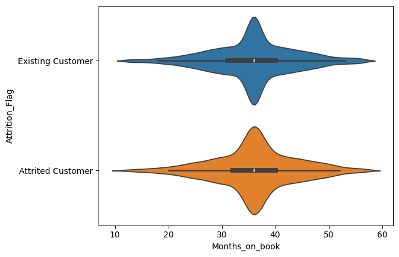

```python
sns.violinplot(data=df, x='Months_on_book', hue='Attrition_Flag', y='Attrition_Flag')
```

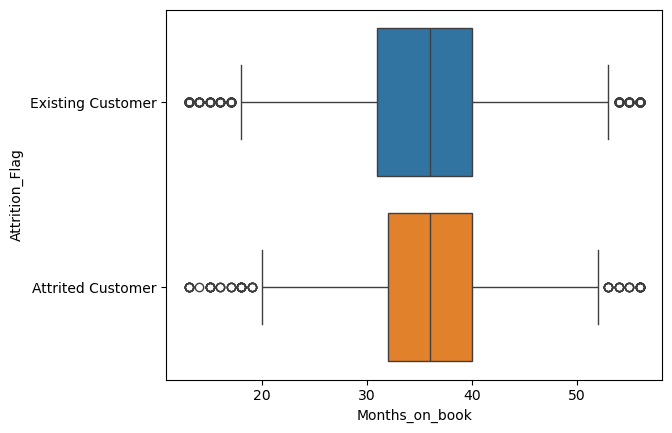

```python
sns.boxplot(data=df, x='Months_on_book', hue='Attrition_Flag', y='Attrition_Flag')
```

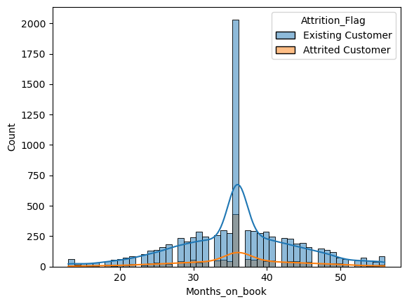

```python
sns.histplot(data=df, x='Months_on_book', hue='Attrition_Flag', kde=True)
```

- ***Months_on_book** shows a **mostly normal distribution***

```python
len(df[df['Months_on_book'] == 36])/len(df)*100
```

```
24.32112175372766
```

- *About* *24.3%** of the total data has **Months_on_book = 36***

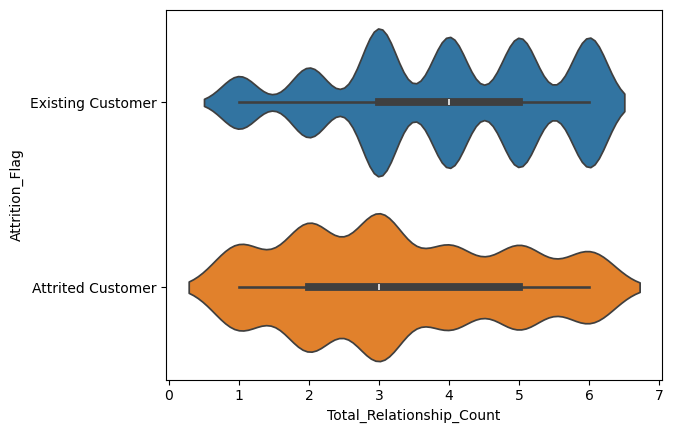

```python
sns.violinplot(data=df, x='Total_Relationship_Count', hue='Attrition_Flag', y='Attrition_Flag')
```

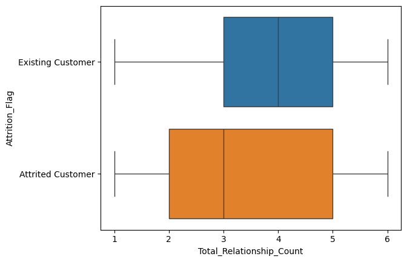

```python
sns.boxplot(data=df, x='Total_Relationship_Count', hue='Attrition_Flag', y='Attrition_Flag')
```

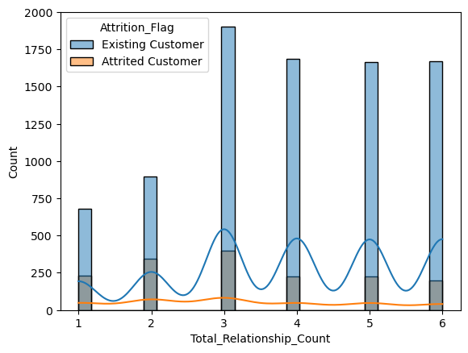

```python
sns.histplot(data=df, x='Total_Relationship_Count', hue='Attrition_Flag', kde=True)
```

- ***Total_Relationship_Count** has **discrete values** from 1-6*
- *Majority of customers have* *more than 3 products** from the bank*

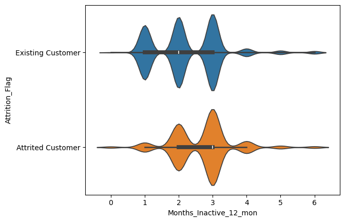

```python
sns.violinplot(data=df, x='Months_Inactive_12_mon', hue='Attrition_Flag', y='Attrition_Flag')
```

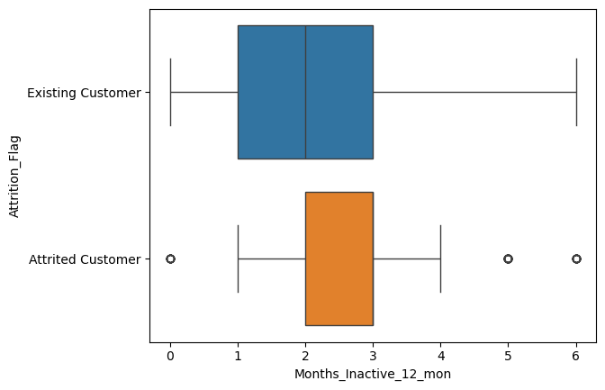

```python
sns.boxplot(data=df, x='Months_Inactive_12_mon', hue='Attrition_Flag', y='Attrition_Flag')
```

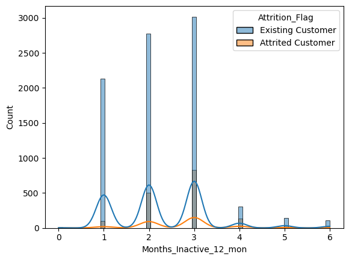

```python
sns.histplot(data=df, x='Months_Inactive_12_mon', hue='Attrition_Flag', kde=True)
```

- ***Months_Inactive_12_mon** has **discrete values** from 0-6*
- ***Most customers have Months_Inactive_12_mon from 1-3** in the dataset*

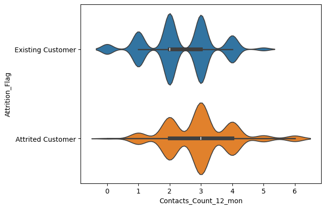

```python
sns.violinplot(data=df, x='Contacts_Count_12_mon', hue='Attrition_Flag', y='Attrition_Flag')
```

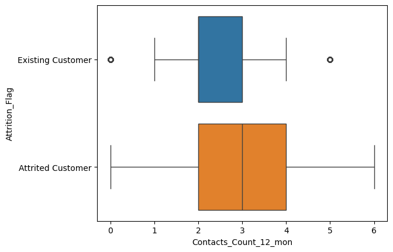

```python
sns.boxplot(data=df, x='Contacts_Count_12_mon', hue='Attrition_Flag', y='Attrition_Flag')
```

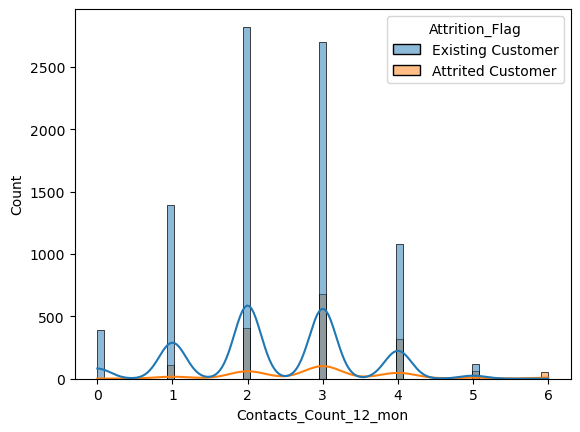

```python
sns.histplot(data=df, x='Contacts_Count_12_mon', hue='Attrition_Flag', kde=True)
```

- ***Contacts_Count_12_mon** has **discrete values** from 0-6*
- *Most customers had* *2-3 connects with the bank in last 12 months***

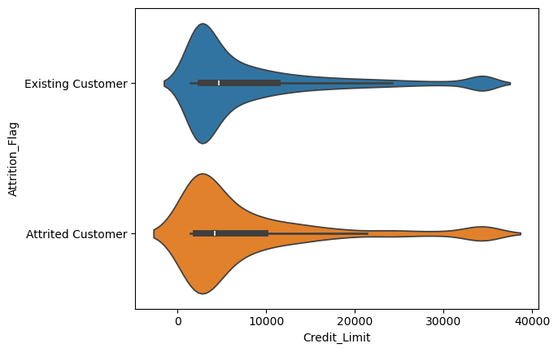

```python
sns.violinplot(data=df, x='Credit_Limit', hue='Attrition_Flag', y='Attrition_Flag')
```

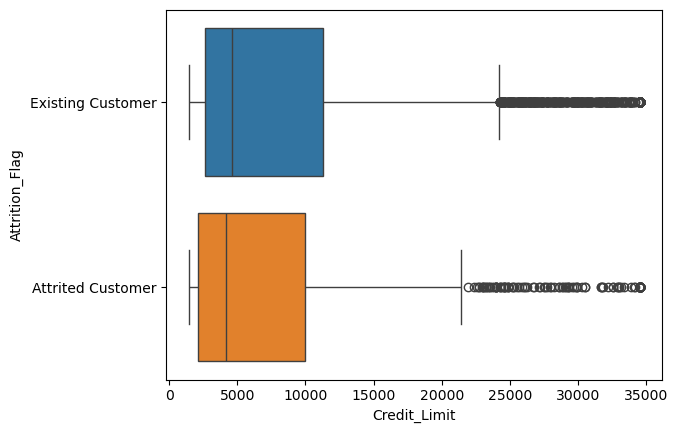

```python
sns.boxplot(data=df, x='Credit_Limit', hue='Attrition_Flag', y='Attrition_Flag')
```

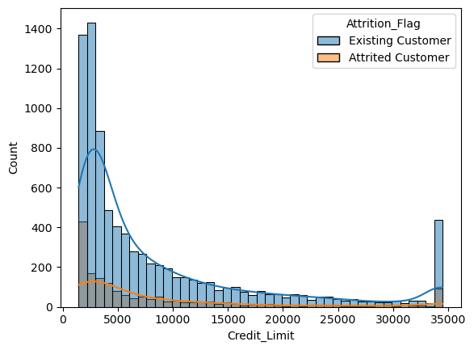

```python
sns.histplot(data=df, x='Credit_Limit', hue='Attrition_Flag', kde=True)
```

- ***Credit_Limit** is a **highly right skewed distribution** with the **maximum number of customers having limit <=\$5000***
- *There are about* *400 customers who show a very high Credit_Limit around \$34000***

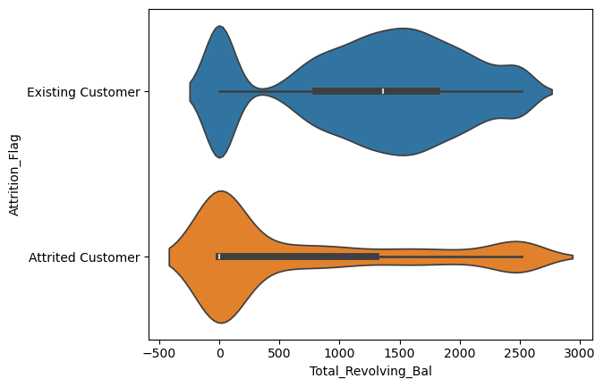

```python
sns.violinplot(data=df, x='Total_Revolving_Bal', hue='Attrition_Flag', y='Attrition_Flag')
```

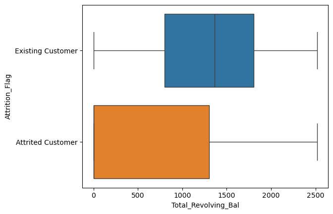

```python
sns.boxplot(data=df, x='Total_Revolving_Bal', hue='Attrition_Flag', y='Attrition_Flag')
```

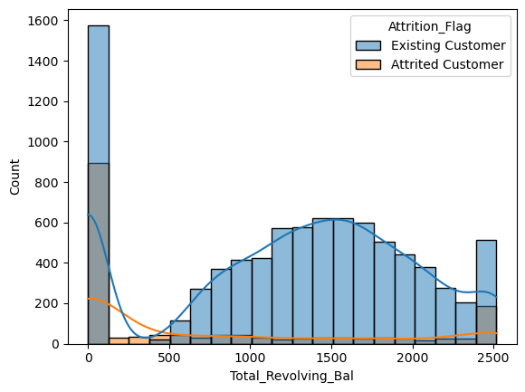

```python
sns.histplot(data=df, x='Total_Revolving_Bal', hue='Attrition_Flag', kde=True)
```

- ***Total_Revolving_Bal** shows an almost **normal distribution from \$500***

```python
df[df['Total_Revolving_Bal'] < 100]['Attrition_Flag'].value_counts()
```

```
Attrition_Flag
Existing Customer    1577
Attrited Customer     893
Name: count, dtype: int64
```

```python
len(df[(df['Total_Revolving_Bal'] < 100) & (df['Attrition_Flag'] == 'Attrited Customer')])/len(df[df['Total_Revolving_Bal'] < 100]) * 100
```

```
36.15384615384615
```

- ***36% of customers** having **Total_Revolving_Bal < \$100 have attrited***

```python
len(df[df['Total_Revolving_Bal'] < 100])/len(df) * 100
```

```
24.390243902439025
```

- *About* *24.4%** of the data has **Total_Revolving_Bal < \$100***

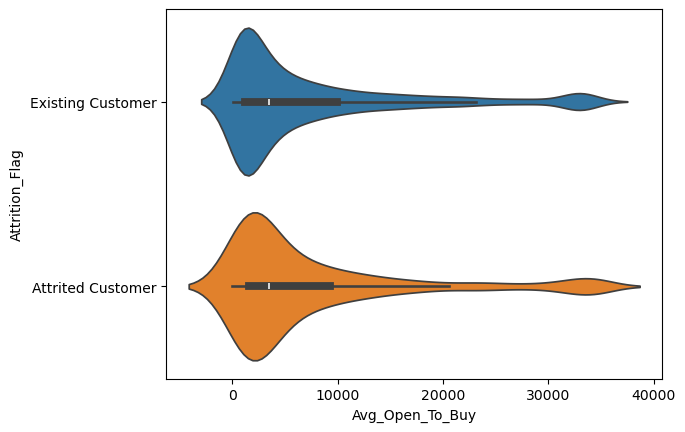

```python
sns.violinplot(data=df, x='Avg_Open_To_Buy', hue='Attrition_Flag', y='Attrition_Flag')
```